# Data 624 - Homework #8

Wei Zhou

2020-11-15

Exercises 7.2 & 7.5 from the K&J book.

```r
#clear the workspace
rm(list = ls())
#load req's packages
library(mlbench)
library(caret)
library(knitr)
library(AppliedPredictiveModeling)
library(corrplot)
```

## 7.2

Friedman (1991) introduced several benchmark data sets create by simulation. One of these simulations used the following nonlinear equation to create data:

$y=10sin(\pi x_1x_2)+20(x_3-0.5)^2 + 10x_4+5x_5+N(0,\sigma^2)$

where the x values are random variables uniformly distributed between [0, 1] (there are also 5 other non-informative variables also created in the simulation). The package mlbench contains a function called mlbench.friedman1 that simulates these data:

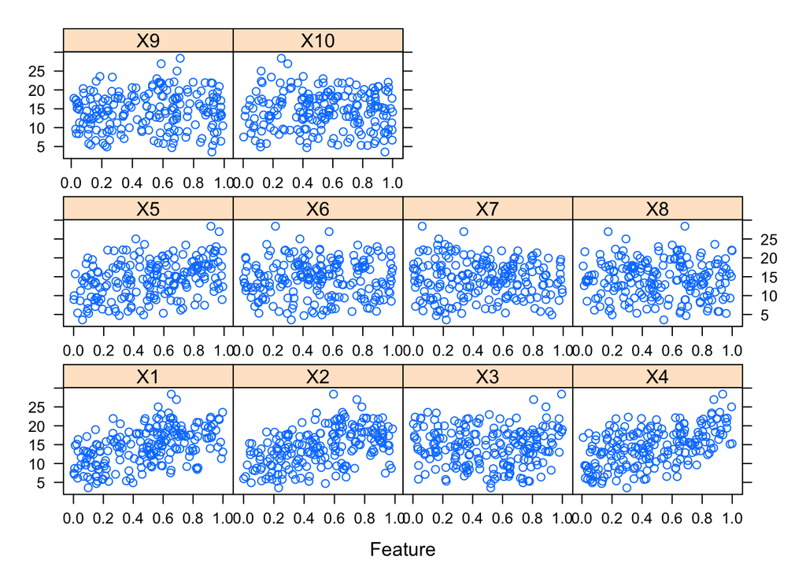

```r
set.seed(200)
trainingData <- mlbench.friedman1(200, sd = 1)
## We convert the 'x' data from a matrix to a data frame
## One reason is that this will give the columns names.
trainingData$x <- data.frame(trainingData$x)
## Look at the data using
featurePlot(trainingData$x, trainingData$y)
```

```r
## or other methods.
## This creates a list with a vector 'y' and a matrix
## of predictors 'x'. Also simulate a large test set to
## estimate the true error rate with good precision:
testData <- mlbench.friedman1(5000, sd = 1)
testData$x <- data.frame(testData$x)
```

Tune several models on these data. For example:

```r
knnModel <- train(x = trainingData$x,
                  y = trainingData$y,
                  method = "knn",
                  preProcess = c("center", "scale"),
                  tuneLength = 10)
knnModel
```

```
## k-Nearest Neighbors
##
## 200 samples
##  10 predictor
##
## Pre-processing: centered (10), scaled (10)
## Resampling: Bootstrapped (25 reps)
## Summary of sample sizes: 200, 200, 200, 200, 200, 200, ...
## Resampling results across tuning parameters:
##
##   k   RMSE      Rsquared   MAE
##    5  3.466085  0.5121775  2.816838
##    7  3.349428  0.5452823  2.727410
##    9  3.264276  0.5785990  2.660026
##   11  3.214216  0.6024244  2.603767
##   13  3.196510  0.6176570  2.591935
##   15  3.184173  0.6305506  2.577482
##   17  3.183130  0.6425367  2.567787
##   19  3.198752  0.6483184  2.592683
##   21  3.188993  0.6611428  2.588787
##   23  3.200458  0.6638353  2.604529
##
## RMSE was used to select the optimal model using the smallest value.
## The final value used for the model was k = 17.
```

```r
knnPred <- predict(knnModel, newdata = testData$x)
postResample(pred = knnPred, obs = testData$y)
```

```
##      RMSE  Rsquared       MAE
## 3.2040595 0.6819919 2.5683461
```

Which models appear to give the best performance? Does MARS select the informative predictors (those named $X1-X5$)?

### MARS:

```r
set.seed(19)  #set the see for the 7.2
grid.MARS <- expand.grid(degree =1:2, nprune=seq(2,14,by=2))
model.MARS <- train(x = trainingData$x,
                    y = trainingData$y,
                    method='bagEarth',
                    tuneGrid = grid.MARS,
                    trControl = trainControl(method = "cv"))
model.MARS
```

```
## Bagged MARS
##
## 200 samples
##  10 predictor
##
## No pre-processing
## Resampling: Cross-Validated (10 fold)
## Summary of sample sizes: 180, 180, 180, 180, 180, 180, ...
## Resampling results across tuning parameters:
##
##   degree  nprune  RMSE      Rsquared   MAE
##   1        2      3.872886  0.5574803  3.1941640
##   1        4      2.633475  0.7410836  2.1128858
##   1        6      1.972961  0.8489500  1.5654086
##   1        8      1.626131  0.8939049  1.2611676
##   1       10      1.597489  0.8984315  1.2257064
##   1       12      1.591183  0.8997029  1.2309777
##   1       14      1.615752  0.8970973  1.2422983
##   2        2      3.839686  0.6053134  3.1622985
##   2        4      2.609962  0.7450580  2.0968921
##   2        6      1.973944  0.8510582  1.5795255
##   2        8      1.521918  0.9083429  1.1879655
##   2       10      1.270410  0.9375227  1.0158870
##   2       12      1.191376  0.9441512  0.9574594
##   2       14      1.202423  0.9436500  0.9654653
##
## RMSE was used to select the optimal model using the smallest value.
## The final values used for the model were nprune = 12 and degree = 2.
```

```r
pred.MARS <- predict(model.MARS, newdata = testData$x)
postResample(pred = pred.MARS, obs = testData$y)
```

```
##      RMSE  Rsquared       MAE
## 1.1284736 0.9490171 0.8964610
```

### Neural Network:

```r
grid.NN <- expand.grid(size = seq(from = 1, to = 5, by = 1),
                        decay = seq(from = 0.01, to = 0.1, by = 0.01),
                        bag = F)
maxW.NN <- 5 * (ncol(trainingData$x) + 1) + 5 + 1
model.NN <- train(x = trainingData$x,
                    y = trainingData$y,
                    method = "avNNet",
                    preProcess = c("center", "scale"),
                    tuneGrid = grid.NN,
                    trControl = trainControl(method = "cv"),
                    linout = TRUE,
                    trace = FALSE,
                    MaxNWts = maxW.NN,
                    maxit = 500)
model.NN
```

```
## Model Averaged Neural Network
##
## 200 samples
##  10 predictor
##
## Pre-processing: centered (10), scaled (10)
## Resampling: Cross-Validated (10 fold)
## Summary of sample sizes: 180, 180, 180, 180, 180, 180, ...
## Resampling results across tuning parameters:
##
##   size  decay  RMSE      Rsquared   MAE
##   1     0.01   2.400546  0.7714549  1.897524
##   1     0.02   2.399852  0.7714851  1.895658
##   1     0.03   2.399925  0.7714154  1.895033
##   1     0.04   2.400182  0.7713267  1.894544
```

[output cut: 50 more lines]

```r
pred.NN <- predict(model.NN, newdata = testData$x)
postResample(pred = pred.NN, obs = testData$y)
```

```
##      RMSE  Rsquared       MAE
## 2.1201492 0.8217987 1.5912055
```

### SVM:

```r
model.SVM <- train(x = trainingData$x,
                   y = trainingData$y,
                   method='svmRadial',
                   tuneLength = 9,
                   trControl = trainControl(method = "cv"))
model.SVM
```

```
## Support Vector Machines with Radial Basis Function Kernel
##
## 200 samples
##  10 predictor
##
## No pre-processing
## Resampling: Cross-Validated (10 fold)
## Summary of sample sizes: 180, 180, 180, 180, 180, 180, ...
## Resampling results across tuning parameters:
##
##   C      RMSE      Rsquared   MAE
##    0.25  2.505555  0.7966271  2.022634
##    0.50  2.279753  0.8109619  1.832437
##    1.00  2.122294  0.8322147  1.706683
##    2.00  1.998040  0.8511927  1.598674
##    4.00  1.874576  0.8670713  1.494258
##    8.00  1.836083  0.8705836  1.456283
##   16.00  1.833906  0.8705585  1.451872
##   32.00  1.833925  0.8705583  1.451880
##   64.00  1.833925  0.8705583  1.451880
##
## Tuning parameter 'sigma' was held constant at a value of 0.06178128
## RMSE was used to select the optimal model using the smallest value.
## The final values used for the model were sigma = 0.06178128 and C = 16.
```

```r
pred.SVM <- predict(model.SVM, newdata = testData$x)
postResample(pred = pred.SVM , obs = testData$y)
```

```
##      RMSE  Rsquared       MAE
## 2.0710406 0.8260815 1.5731468
```

### Summary

First we will look at model performance:

```r
model.perf <- cbind(data.frame(postResample(pred = knnPred, obs = testData$y)),
                    data.frame(postResample(pred = pred.MARS, obs = testData$y)),
                    data.frame(postResample(pred = pred.NN, obs = testData$y)),
                    data.frame(postResample(pred = pred.SVM, obs = testData$y)))
colnames(model.perf) <- c("KNN","MARS","NN","SVM")
kable(round(model.perf,2))
```

|  | KNN | MARS | NN | SVM |
| --- | --- | --- | --- | --- |
| RMSE | 3.20 | 1.13 | 2.12 | 2.07 |
| Rsquared | 0.68 | 0.95 | 0.82 | 0.83 |
| MAE | 2.57 | 0.90 | 1.59 | 1.57 |

For this particular problem, we can see that the MARS model the superior performer. MARS shows the smallest error stats and the higest Rsquared.

```r
var.importance <- cbind(varImp(knnModel)[[1]],
                        varImp(model.NN)[[1]],
                        varImp(model.SVM)[[1]])
colnames(var.importance) <- c("KNN","NN","SVM")
kable(round(var.importance))
```

|  | KNN | NN | SVM |
| --- | --- | --- | --- |
| X1 | 96 | 96 | 96 |
| X2 | 90 | 90 | 90 |
| X3 | 30 | 30 | 30 |
| X4 | 100 | 100 | 100 |
| X5 | 45 | 45 | 45 |
| X6 | 1 | 1 | 1 |
| X7 | 0 | 0 | 0 |
| X8 | 3 | 3 | 3 |
| X9 | 6 | 6 | 6 |
| X10 | 6 | 6 | 6 |

All of the models correctly identify $X1-X5$ as the important variables while almost identifying $X6-X10$ as not important.

## 7.5

Exercise 6.3 describes data for a chemical manufacturing process. Use the same data imputation, data splitting, and pre-processing steps as before and train several nonlinear regression models.

```r
set.seed(19) #reset the seed for Q 7.5
data(ChemicalManufacturingProcess)
chem <- ChemicalManufacturingProcess
#impute using knn
chem.imp <- preProcess(chem[,2:ncol(chem)], method=c('knnImpute'))
chem <- cbind(chem$Yield,predict(chem.imp, chem[,2:ncol(chem)]))
colnames(chem)[1] <- "Yield"
#split 70/30
n <-  floor(0.70 * nrow(chem))
idx <- sample(seq_len(nrow(chem)), size = n)
train <- chem[idx, ]
test <- chem[-idx, ]
```

```r
knnModel <- train(x=train[,-1],
                  y=train$Yield,
                  method = "knn",
                  preProcess = c("center", "scale"),
                  tuneLength = 10)
knnModel
```

```
## k-Nearest Neighbors
##
## 123 samples
##  57 predictor
##
## Pre-processing: centered (57), scaled (57)
## Resampling: Bootstrapped (25 reps)
## Summary of sample sizes: 123, 123, 123, 123, 123, 123, ...
## Resampling results across tuning parameters:
##
##   k   RMSE      Rsquared   MAE
##    5  1.433790  0.3687691  1.136364
##    7  1.410122  0.3732909  1.120532
##    9  1.414762  0.3668017  1.121848
##   11  1.421107  0.3607650  1.138411
##   13  1.437570  0.3437580  1.151992
##   15  1.443993  0.3408658  1.164805
##   17  1.453462  0.3358697  1.172275
##   19  1.466765  0.3268167  1.184108
##   21  1.471999  0.3259854  1.191366
##   23  1.484340  0.3177842  1.205743
##
## RMSE was used to select the optimal model using the smallest value.
## The final value used for the model was k = 7.
```

```r
knnPred <- predict(knnModel, newdata = test[,-1])
postResample(pred = knnPred, obs = test$Yield)
```

```
##      RMSE  Rsquared       MAE
## 1.3705821 0.5888388 1.0641004
```

```r
grid.MARS <- expand.grid(degree =1:2, nprune=seq(2,14,by=2))
model.MARS <- train(x=train[,-1],
                    y=train$Yield,
                    method='bagEarth',
                    tuneGrid = grid.MARS,
                    trControl = trainControl(method = "cv"))
model.MARS
```

```
## Bagged MARS
##
## 123 samples
##  57 predictor
##
## No pre-processing
## Resampling: Cross-Validated (10 fold)
## Summary of sample sizes: 111, 111, 111, 110, 111, 111, ...
## Resampling results across tuning parameters:
##
##   degree  nprune  RMSE      Rsquared   MAE
##   1        2      1.350900  0.4941127  1.108734
##   1        4      1.221729  0.5606339  1.005637
##   1        6      1.317405  0.5269844  1.036788
##   1        8      1.450711  0.4857636  1.091201
##   1       10      1.513744  0.5216115  1.071108
##   1       12      1.819527  0.4806020  1.166368
##   1       14      1.851979  0.4982395  1.189922
##   2        2      1.373078  0.4893161  1.134307
##   2        4      1.251562  0.5249608  1.027347
##   2        6      1.503673  0.5054010  1.084645
##   2        8      1.607509  0.5241377  1.098866
##   2       10      1.422078  0.5151927  1.026461
##   2       12      1.645545  0.5263822  1.102896
##   2       14      1.415669  0.5364610  1.019540
##
## RMSE was used to select the optimal model using the smallest value.
## The final values used for the model were nprune = 4 and degree = 1.
```

```r
pred.MARS <- predict(model.MARS, newdata = test[,-1])
postResample(pred = pred.MARS, obs = test$Yield)
```

```
##      RMSE  Rsquared       MAE
## 1.1358439 0.6864584 0.9029211
```

```r
grid.NN <- expand.grid(size = seq(from = 1, to = 5, by = 1),
                        decay = seq(from = 0.01, to = 0.1, by = 0.01),
                        bag = F)
maxW.NN <- 5 * (ncol(train[,-1]) + 1) + 5 + 1
model.NN <- train(x=train[,-1],
                 y=train$Yield,
                    method = "avNNet",
                    preProcess = c("center", "scale"),
                    tuneGrid = grid.NN,
                    trControl = trainControl(method = "cv"),
                    linout = TRUE,
                    trace = FALSE,
                    MaxNWts = maxW.NN ,
                    maxit = 500)
model.NN
```

```
## Model Averaged Neural Network
##
## 123 samples
##  57 predictor
##
## Pre-processing: centered (57), scaled (57)
## Resampling: Cross-Validated (10 fold)
## Summary of sample sizes: 111, 110, 111, 110, 111, 111, ...
## Resampling results across tuning parameters:
##
##   size  decay  RMSE      Rsquared   MAE
##   1     0.01   1.393954  0.4957296  1.114959
##   1     0.02   1.495886  0.4841757  1.234266
##   1     0.03   1.499004  0.4544222  1.238226
##   1     0.04   1.445131  0.4812720  1.166866
```

[output cut: 50 more lines]

```r
pred.NN <- predict(model.NN, newdata = test[,-1])
postResample(pred = pred.NN, obs = test$Yield)
```

```
##      RMSE  Rsquared       MAE
## 1.8672838 0.3525522 1.3521986
```

```r
model.SVM <- train(x=train[,-1],
                   y=train$Yield,
                   method='svmRadial',
                   tuneLength = 9,
                   trControl = trainControl(method = "cv"))
model.SVM
```

```
## Support Vector Machines with Radial Basis Function Kernel
##
## 123 samples
##  57 predictor
##
## No pre-processing
## Resampling: Cross-Validated (10 fold)
## Summary of sample sizes: 111, 110, 111, 111, 111, 111, ...
## Resampling results across tuning parameters:
##
##   C      RMSE      Rsquared   MAE
##    0.25  1.394170  0.4961883  1.1646441
##    0.50  1.299529  0.5376299  1.0806526
##    1.00  1.210805  0.5839863  1.0025696
##    2.00  1.122409  0.6314188  0.9339997
##    4.00  1.072147  0.6535913  0.8869301
##    8.00  1.060473  0.6545789  0.8836760
##   16.00  1.060473  0.6545789  0.8836760
##   32.00  1.060473  0.6545789  0.8836760
##   64.00  1.060473  0.6545789  0.8836760
##
## Tuning parameter 'sigma' was held constant at a value of 0.01616608
## RMSE was used to select the optimal model using the smallest value.
## The final values used for the model were sigma = 0.01616608 and C = 8.
```

```r
pred.SVM <- predict(model.SVM, newdata = test[,-1])
postResample(pred = pred.SVM , obs = test$Yield)
```

```
##      RMSE  Rsquared       MAE
## 1.3149519 0.6204367 1.0100227
```

### A

Which nonlinear regression model gives the optimal resampling and test set performance?

```r
model.perf <- cbind(data.frame(postResample(pred = knnPred, obs =test$Yield)),
                    data.frame(postResample(pred = pred.MARS, obs = test$Yield)),
                    data.frame(postResample(pred = pred.NN, obs = test$Yield)),
                    data.frame(postResample(pred = pred.SVM, obs = test$Yield)))
colnames(model.perf) <- c("KNN","MARS","NN","SVM")
kable(round(model.perf,2))
```

|  | KNN | MARS | NN | SVM |
| --- | --- | --- | --- | --- |
| RMSE | 1.37 | 1.14 | 1.87 | 1.31 |
| Rsquared | 0.59 | 0.69 | 0.35 | 0.62 |
| MAE | 1.06 | 0.90 | 1.35 | 1.01 |

### B

Which predictors are most important in the optimal nonlinear regression model? Do either the biological or process variables dominate the list? How do the top ten important predictors compare to the top ten predictors from the optimal linear model?

```r
var.importance <- cbind(varImp(knnModel)[[1]],
                        varImp(model.NN)[[1]],
                        varImp(model.SVM)[[1]])
colnames(var.importance) <- c("KNN","NN","SVM")
kable(round(var.importance))
```

|  | KNN | NN | SVM |
| --- | --- | --- | --- |
| BiologicalMaterial01 | 46 | 46 | 46 |
| BiologicalMaterial02 | 64 | 64 | 64 |
| BiologicalMaterial03 | 91 | 91 | 91 |
| BiologicalMaterial04 | 47 | 47 | 47 |
| BiologicalMaterial05 | 8 | 8 | 8 |
| BiologicalMaterial06 | 95 | 95 | 95 |
| BiologicalMaterial07 | 4 | 4 | 4 |
| BiologicalMaterial08 | 48 | 48 | 48 |
| BiologicalMaterial09 | 57 | 57 | 57 |
| BiologicalMaterial10 | 22 | 22 | 22 |
| BiologicalMaterial11 | 52 | 52 | 52 |
| BiologicalMaterial12 | 75 | 75 | 75 |
| ManufacturingProcess01 | 28 | 28 | 28 |
| ManufacturingProcess02 | 32 | 32 | 32 |
| ManufacturingProcess03 | 1 | 1 | 1 |
| ManufacturingProcess04 | 29 | 29 | 29 |
| ManufacturingProcess05 | 7 | 7 | 7 |
| ManufacturingProcess06 | 64 | 64 | 64 |
| ManufacturingProcess07 | 0 | 0 | 0 |
| ManufacturingProcess08 | 0 | 0 | 0 |
| ManufacturingProcess09 | 72 | 72 | 72 |
| ManufacturingProcess10 | 29 | 29 | 29 |
| ManufacturingProcess11 | 53 | 53 | 53 |
| ManufacturingProcess12 | 29 | 29 | 29 |
| ManufacturingProcess13 | 88 | 88 | 88 |
| ManufacturingProcess14 | 19 | 19 | 19 |
| ManufacturingProcess15 | 22 | 22 | 22 |
| ManufacturingProcess16 | 26 | 26 | 26 |
| ManufacturingProcess17 | 66 | 66 | 66 |
| ManufacturingProcess18 | 32 | 32 | 32 |
| ManufacturingProcess19 | 9 | 9 | 9 |
| ManufacturingProcess20 | 23 | 23 | 23 |
| ManufacturingProcess21 | 13 | 13 | 13 |
| ManufacturingProcess22 | 0 | 0 | 0 |
| ManufacturingProcess23 | 4 | 4 | 4 |
| ManufacturingProcess24 | 15 | 15 | 15 |
| ManufacturingProcess25 | 28 | 28 | 28 |
| ManufacturingProcess26 | 22 | 22 | 22 |
| ManufacturingProcess27 | 17 | 17 | 17 |
| ManufacturingProcess28 | 13 | 13 | 13 |
| ManufacturingProcess29 | 57 | 57 | 57 |
| ManufacturingProcess30 | 42 | 42 | 42 |
| ManufacturingProcess31 | 62 | 62 | 62 |
| ManufacturingProcess32 | 100 | 100 | 100 |
| ManufacturingProcess33 | 48 | 48 | 48 |
| ManufacturingProcess34 | 6 | 6 | 6 |
| ManufacturingProcess35 | 14 | 14 | 14 |
| ManufacturingProcess36 | 57 | 57 | 57 |
| ManufacturingProcess37 | 15 | 15 | 15 |
| ManufacturingProcess38 | 0 | 0 | 0 |
| ManufacturingProcess39 | 1 | 1 | 1 |
| ManufacturingProcess40 | 0 | 0 | 0 |
| ManufacturingProcess41 | 0 | 0 | 0 |
| ManufacturingProcess42 | 0 | 0 | 0 |
| ManufacturingProcess43 | 2 | 2 | 2 |
| ManufacturingProcess44 | 14 | 14 | 14 |
| ManufacturingProcess45 | 1 | 1 | 1 |